# Primera Sesión

Gabriel N. Camargo-Toledo

30/10/2020

# Introducción

En esta primera sesión empezaremos de una vez a usar R para hacer gráficas. Prefiero como introducción empezar de una vez a hacer gráficas bonitas como motivación, es algo que nos muestra rápidamente el poder R y nos permite empezar a entender algunos conceptos importantes.

## Texto guía

Mi texto guía es: https://r4ds.had.co.nz/. La estructura de las sesiones sigue más o menos este texto. Además aprendí bastante atendiendo la clase de Dave Armstrong en ICPSR, que tiene todas sus clases disponibles en: https://quantoid.net/teachicpsr/. En caso de problemas, además de revisar en estos textos guías, normalmente google es una buena fuente de información.

## Qué vamos a hacer hoy?

- Gráficas en R (usando ggplot2)
- Qué son paquetes, y porqué usar el tidyverse
- Porqué (y porqué no) usar R

# Gráficas

## A lo que queremos llegar

Al final de esta sesión llegaremos a hacer algo como esto:

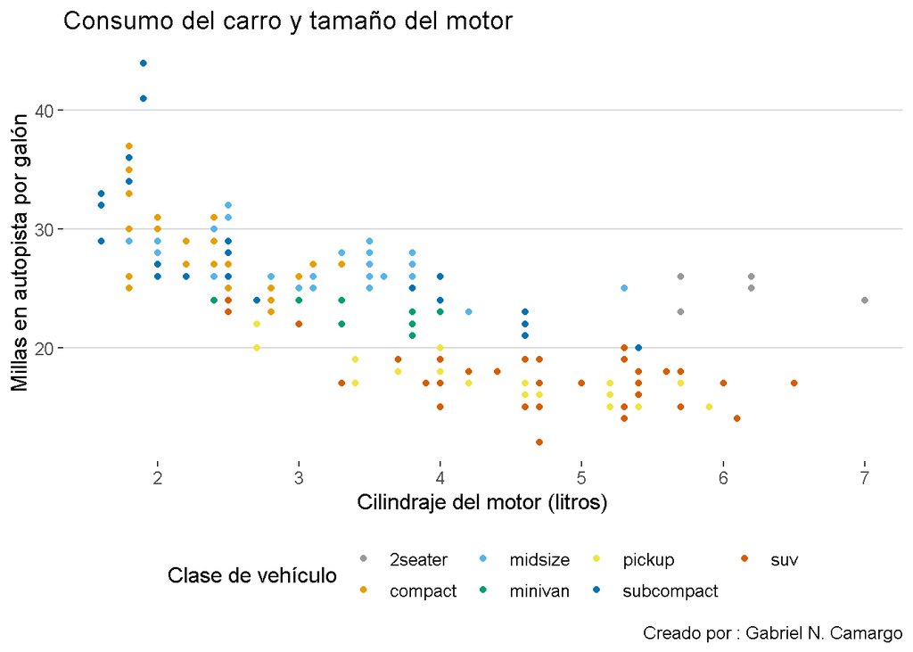

## Gráficos rápidos

En primer lugar vamos a usar la función qplot() para crear un gráfico rápido de precios de diamantes y sus quilates.

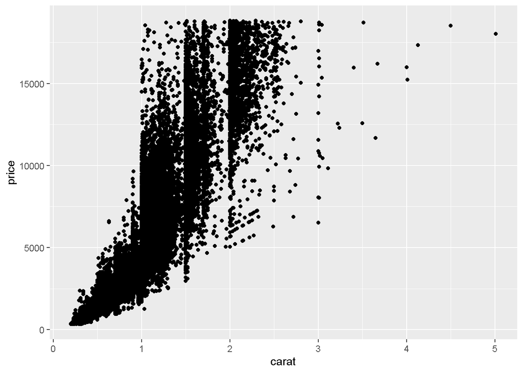

```r
qplot(x=carat, y=price, data=diamonds)
```

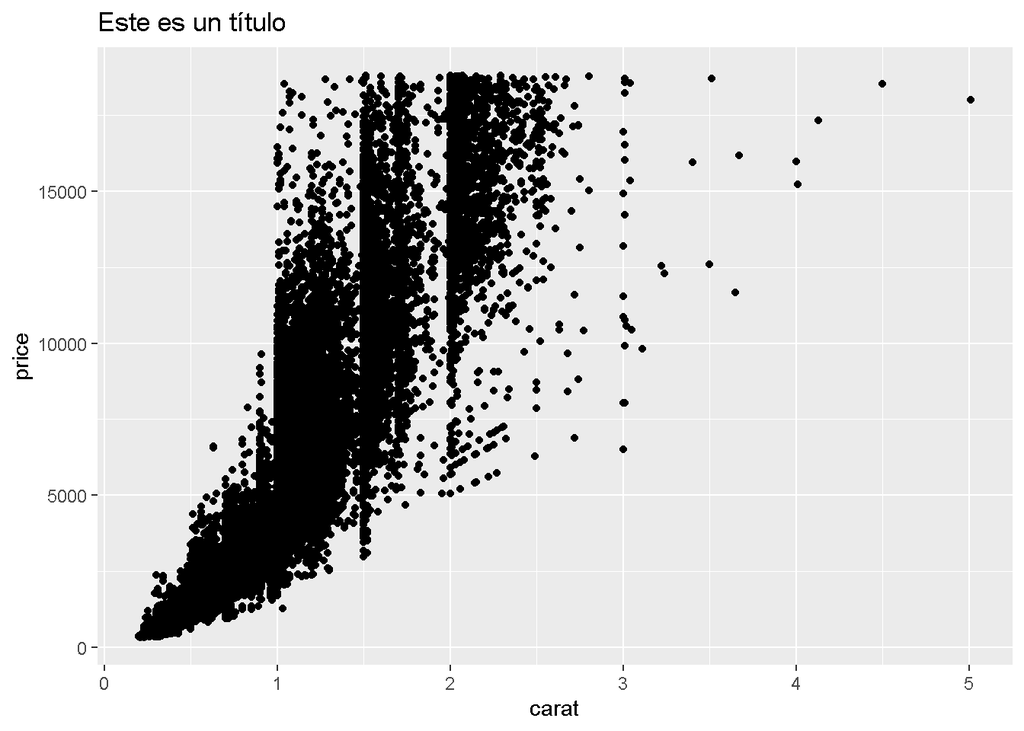

```r
qplot(x=carat, y=price, data=diamonds)  +  ggtitle("Este es un título")
```

qplot sirve para hacer gráficas rápidas (quick plots), tiene unos defaults útiles pero no son bonitas y tienen menos funcionalidad que ggplot.

### Ejercicios

- Q1/ ¿Qué puede ser mejor en esta gráfica? ¿Qué significa cada argumento de la función (x, y, data)?
- Q2/ ¿Qué significa ggtitle y porqué uso " + "?

## Capas de un ggplot

Hacer esta misma gráfica usando ggplot requiere ser más detallado, esa es la ventaja del qplot.

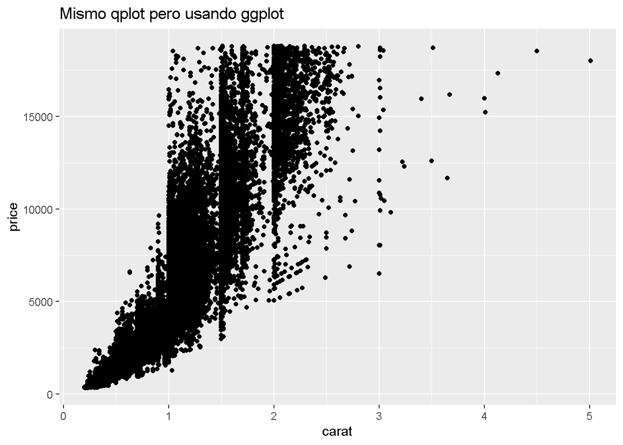

```r
ggplot(data=diamonds, mapping = aes(x=carat, y=price))  +  geom_point()  +  labs(title = "Mismo qplot pero usando ggplot")
```

Un ggplot tiene que tener mínimo dos capas: `ggplot` y `geom`:

- La capa `ggplot` le dice a R que “inicialice” la gráfica. Además se puede especificar de donde provienen los datos con el argumento `data` y el mapeo estético con `mapping = aes()`.
- La capa `geom` le asigna un tipo de gráfica.

Con estos dos elementos R ya crea una gráfica. Pero se pueden añadir otras cosas. Eso es lo que vamos a hacer en la siguiente sección

### Ejercicios

- Q1/ ¿Qué pasa si cambio `labs(title = ...)` por `ggtitle(...)`?

## Usando capas como objetos

Para sacar el mayor provecho a las capas, y no tener que volver a escribir siempre lo mismo, es bueno guardar las distintas capas en objetos de R. Un objeto siempre se asigna usando `<-`. Yo siempre le pongo nombres claros a los objetos, para que al leer mi código en el futuro sepa que son:

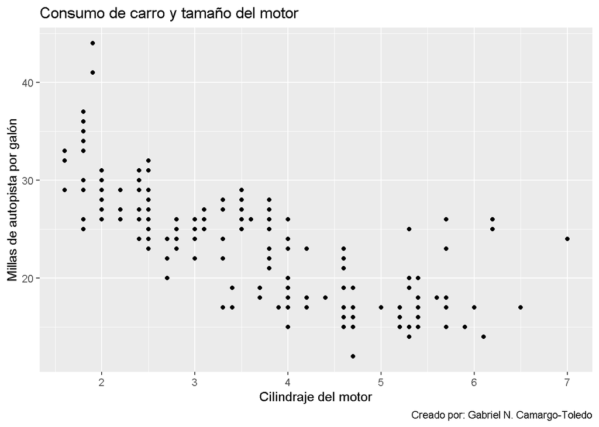

```r
data_plot <- ggplot(data=mpg, mapping = aes(x=displ, y=hwy))
poi_plot <- geom_point()
text_plot <- labs(title = "Consumo de carro y tamaño del motor", x = "Cilindraje del motor", y="Millas de autopista por galón", caption = "Creado por: Gabriel N. Camargo-Toledo")

data_plot + poi_plot + text_plot
```

El objeto `data_plot` son los datos y la estética del gráfico. `poi_plot` es la forma del gráfico, y `text_plot` los textos que va a tener. Ahora para incluir además una linea de loess a la gráfica, solo tengo que crear un nuevo objeto y añadirlo:

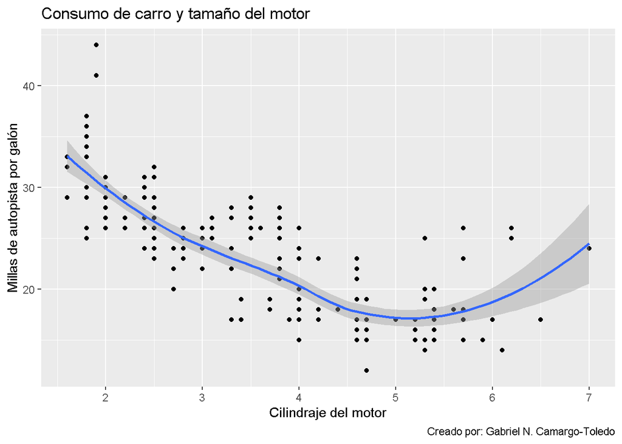

```r
smo_plot <- geom_smooth()
data_plot + poi_plot + smo_plot + text_plot
```

Las capas me permiten incluir más cosas en la gráfica sin tener que hacer todo de nuevo. Esto acelera el trabajo y reduce la cantidad de errores que se cometen.

## Otra variable en la misma gráfica

En algunos casos es interesante hacer la misma gráfica pero incluir más información. En este caso voy a separar por tipos de vehículos. Hay distintar maneras de hacer esto.

Una opción es cambiar el tamaño de los puntos:

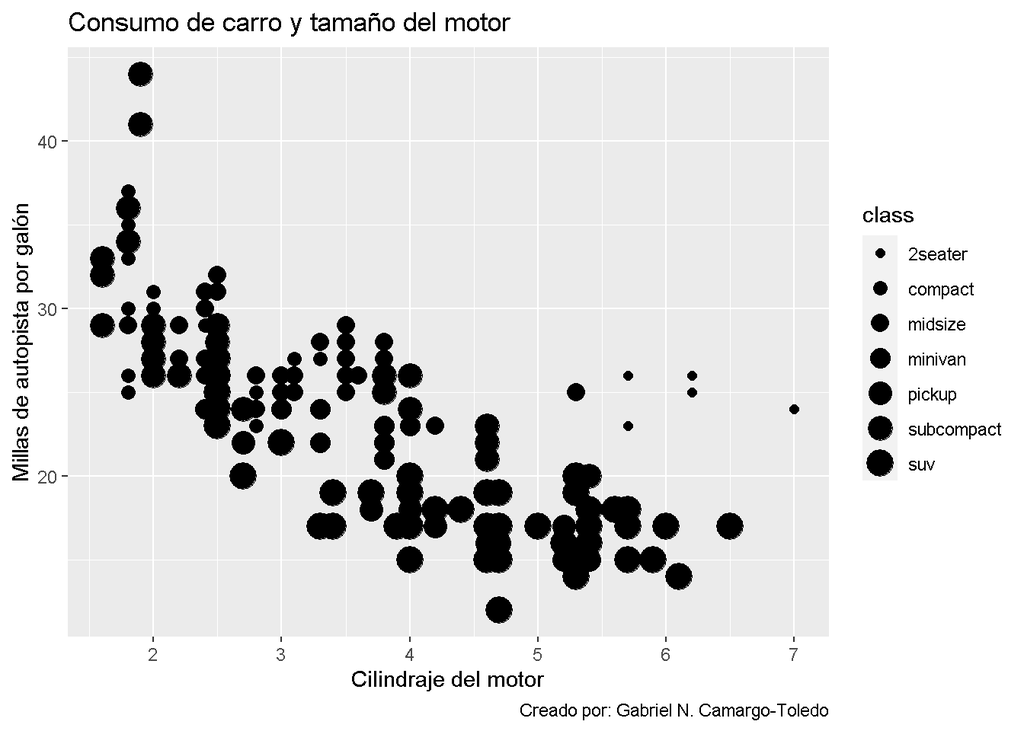

```r
poi_plot <- geom_point(mapping = aes(size = class))

data_plot + poi_plot + text_plot
```

Para que sea más claro, eliminé el smooth. Incluir esta información fue fácil, solo tuve que incluir `mapping` al geom_point.

En este caso cambiar el tamaño de los puntos no es muy útil. Esta forma es mejor cuando la variable que se va a usar para separar tiene un orden. Intentemos ahora cambiando la forma:

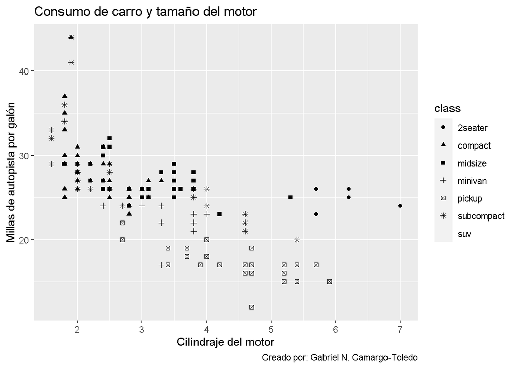

```r
poi_plot <- geom_point(mapping = aes(shape = class))

data_plot + poi_plot + text_plot
```

Esta gráfica podría servir, pero vemos que tiene la limitación de que solo tiene hasta 6 formas. Es por eso que SUV no sale. Otra opción es cambiar la intensidad del color.

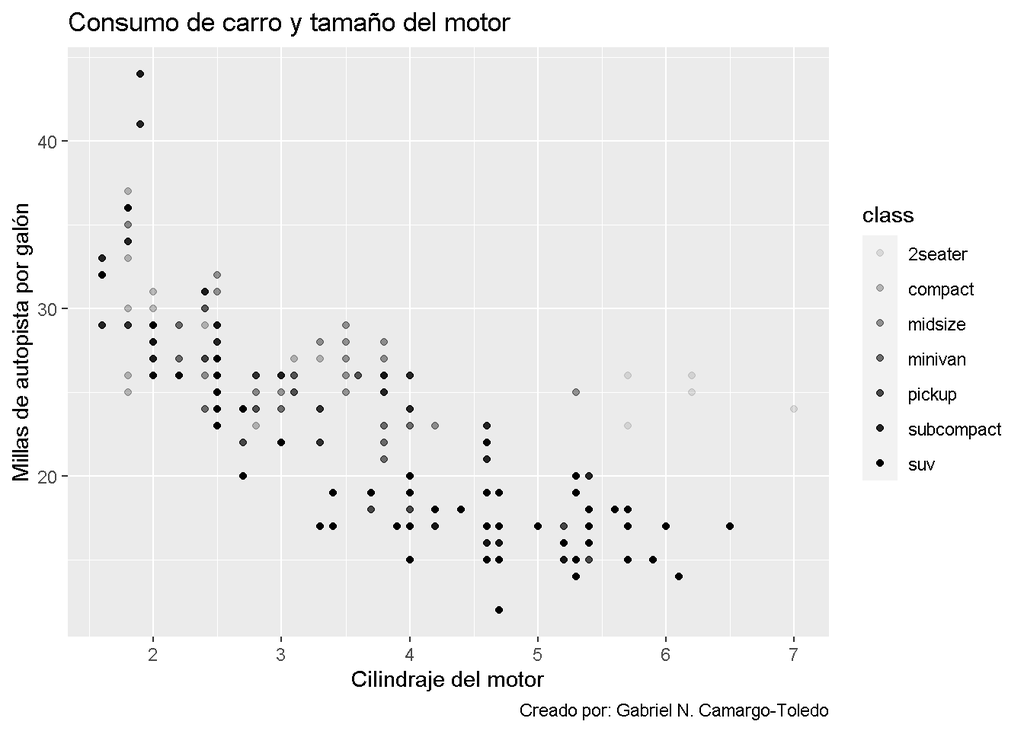

```r
poi_plot <- geom_point(mapping = aes(alpha = class))

data_plot + poi_plot + text_plot
```

Esta funciona mejor, y en este caso es una buena opción si hay limitaciones de no poder usar colores. Puede ser poco claro para algunas personas con problemas de visión ver los 2seater. Otra opción es hacer las gráficas por aparte para cada tipo de vehículo. Esto requiere algo diferente, usar `facet`:

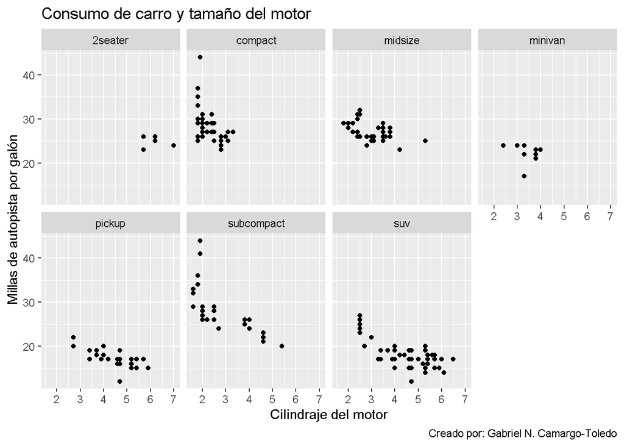

```r
poi_plot <- geom_point()
fac_plot <- facet_wrap(~ class, nrow = 2)

data_plot + poi_plot + fac_plot + text_plot
```

Finalmente podemos usar colores para separar la gráfica. Esta es una buena gráfica, clara y que permite hacer análisis sobre las variables en cuestión.

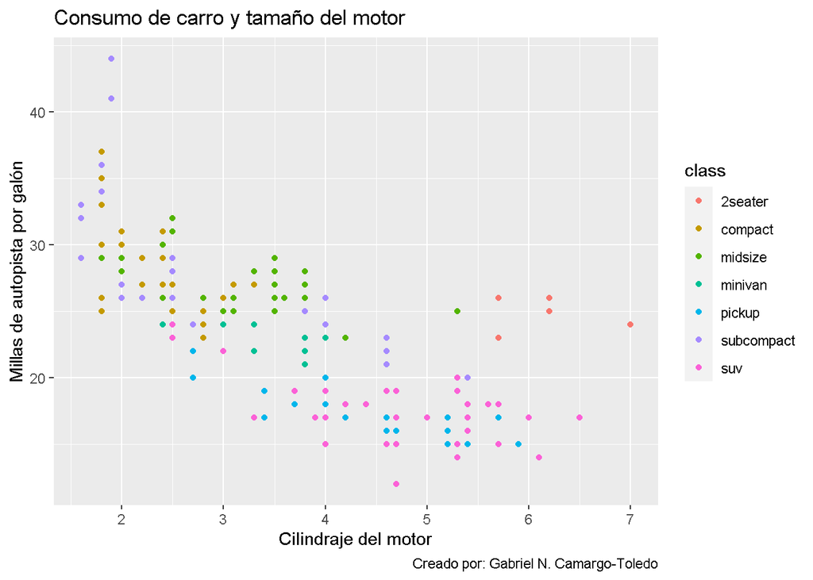

```r
poi_plot <- geom_point(mapping = aes(colour = class))

data_plot + poi_plot + text_plot
```

## Colores y temas de ggplot

La última gráfica ya es una gráfica autocontenida y útil que nos permite hacer un buen análisis. Pero tiene algunos problemas. Por un lado, los colores default no son amigables con personas con deficiencia en la visión de los colores. Suena trivial, pero puede llegar a ser un problema. En EEUU 1 de cada 12 hombres sufre de esto, y para ellos estas gráficas pueden no ser útiles. En este caso voy a usar la paleta disponible en: https://www.cookbook-r.com/Graphs/Colors_(ggplot2)/#a-colorblind-friendly-palette

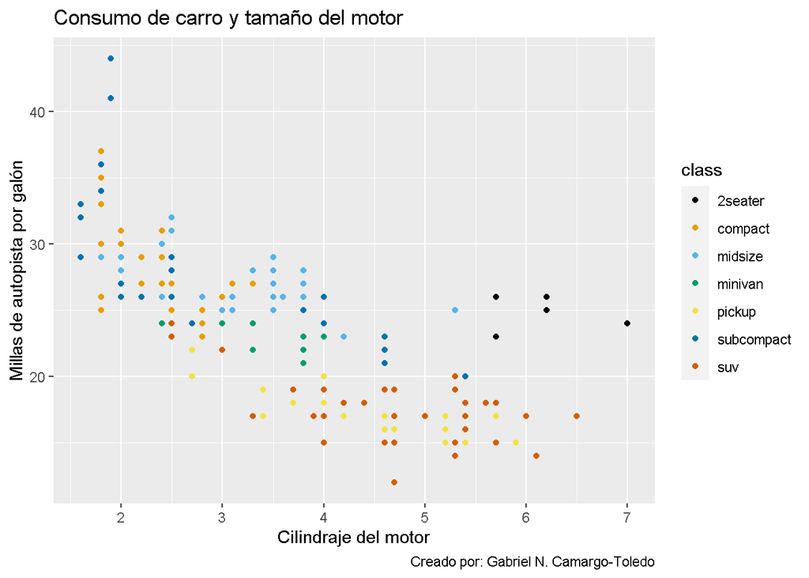

```r
cbbPal_color <- c( "#000000" , "#E69F00" , "#56B4E9" , "#009E73" , "#F0E442" , "#0072B2" , "#D55E00" , "#CC79A7")

data_plot + poi_plot + text_plot + scale_colour_manual(values=cbbPal_color)
```

Esta gráfica ya es amigable con los daltónicos. Además ggplot nos permite cambiar otros elementos de la gráfica como el fondo o la fuente. Esto se hace con la capa `theme`. Hay dos maneras de usar esta capa, manualmente cambiando los distintos elementos de la gráfica, o usando themes preexistentes. Por ahora vamos a usar themes preexistentes, que se pueden mirar en este link: https://ggplot2.tidyverse.org/reference/ggtheme.html

Por ahora vamos a ver tres themes distintos: `theme_dark`, `theme_bw` y `theme_minimal`

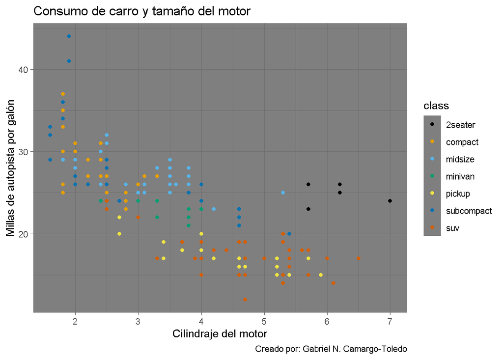

```r
data_plot + poi_plot + text_plot + theme_dark() + scale_colour_manual(values=cbbPal_color)
```

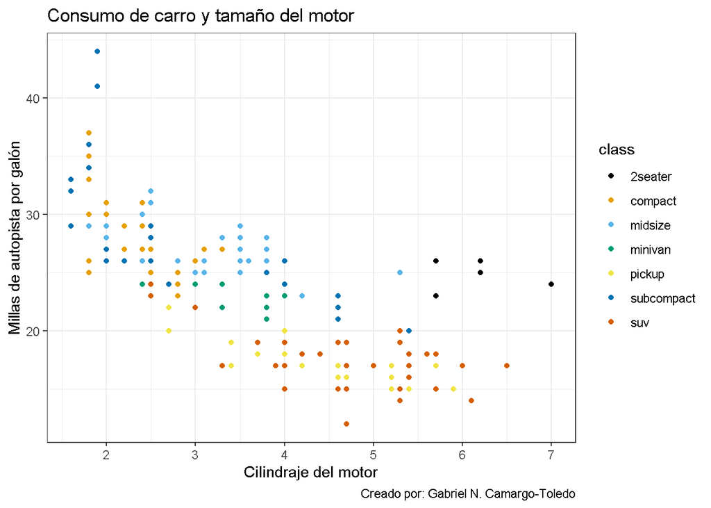

```r
data_plot + poi_plot + text_plot + theme_bw() + scale_colour_manual(values=cbbPal_color)
```

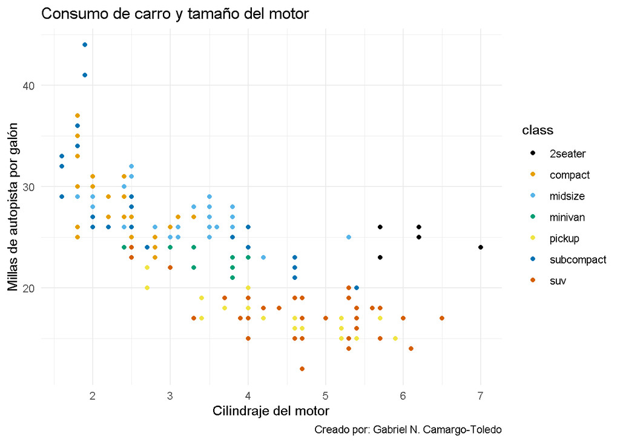

```r
data_plot + poi_plot + text_plot + theme_minimal() + scale_colour_manual(values=cbbPal_color)
```

Además de los themes que están en ggplot, también podemos descargar el paquete `ggthemes`, se pueden ver acá: https://yutannihilation.github.io/allYourFigureAreBelongToUs/ggthemes/

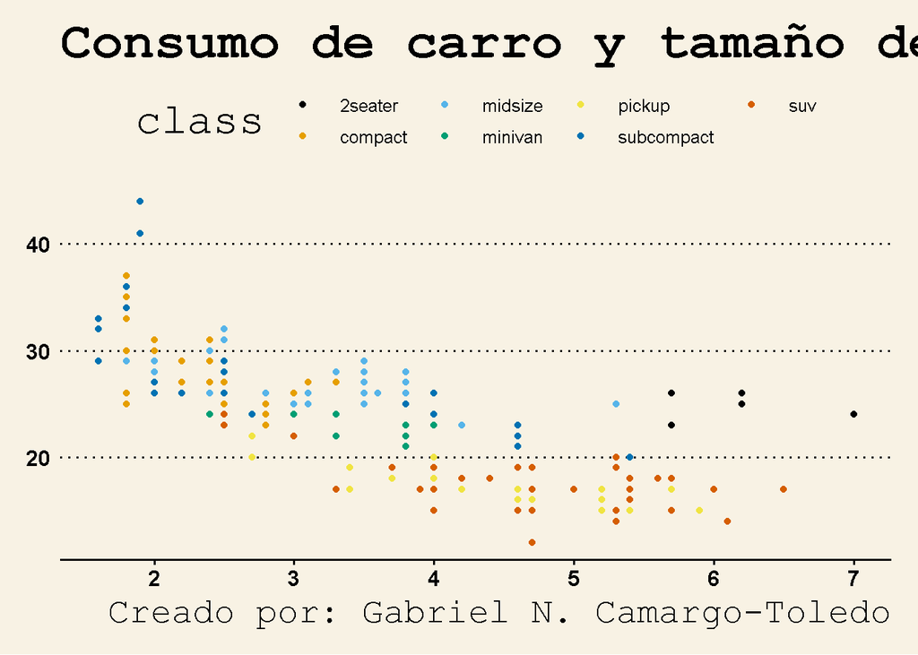

```r
library(ggthemes)
data_plot + poi_plot + text_plot + theme_wsj() + scale_colour_manual(values=cbbPal_color)
```

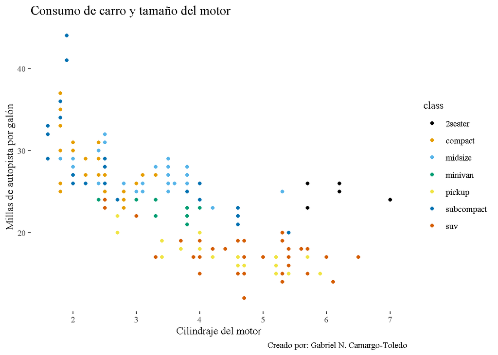

```r
data_plot + poi_plot + text_plot + theme_tufte() + scale_colour_manual(values=cbbPal_color)
```

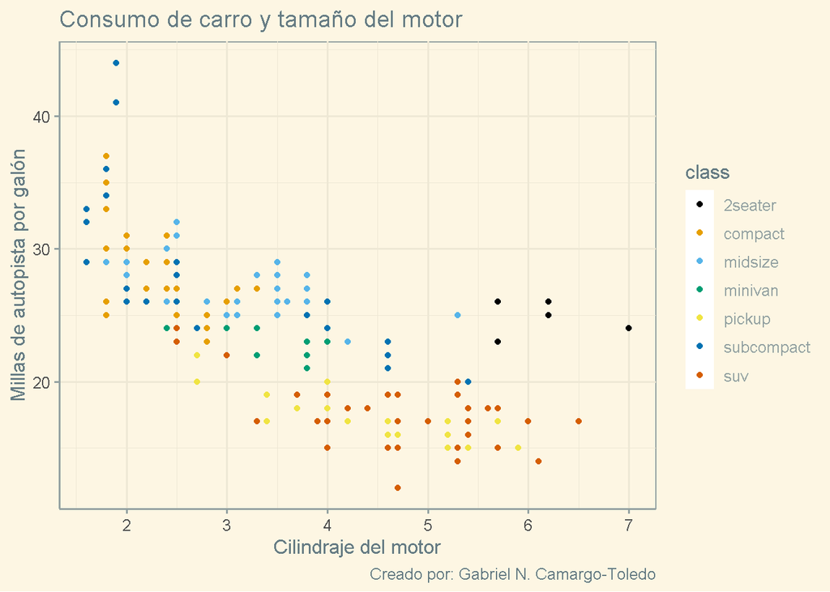

```r
data_plot + poi_plot + text_plot + theme_solarized() + scale_colour_manual(values=cbbPal_color)
```

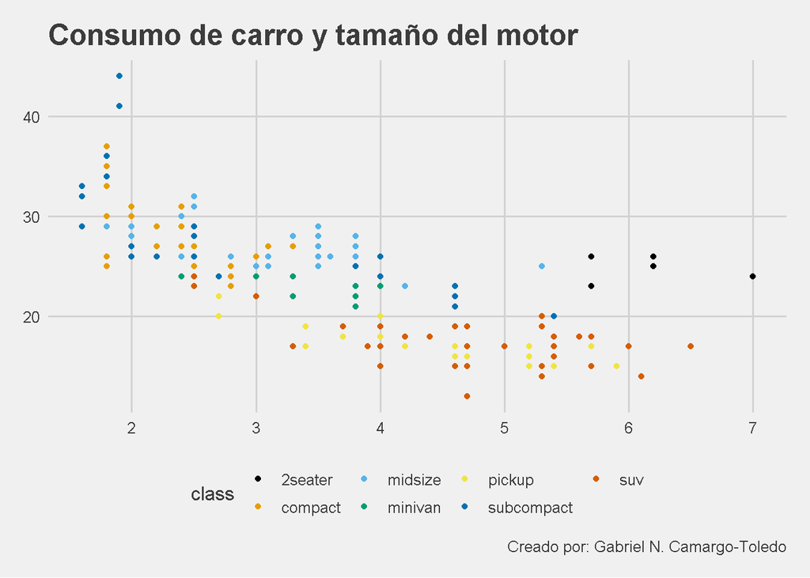

```r
data_plot + poi_plot + text_plot + theme_fivethirtyeight() + scale_colour_manual(values=cbbPal_color)
```

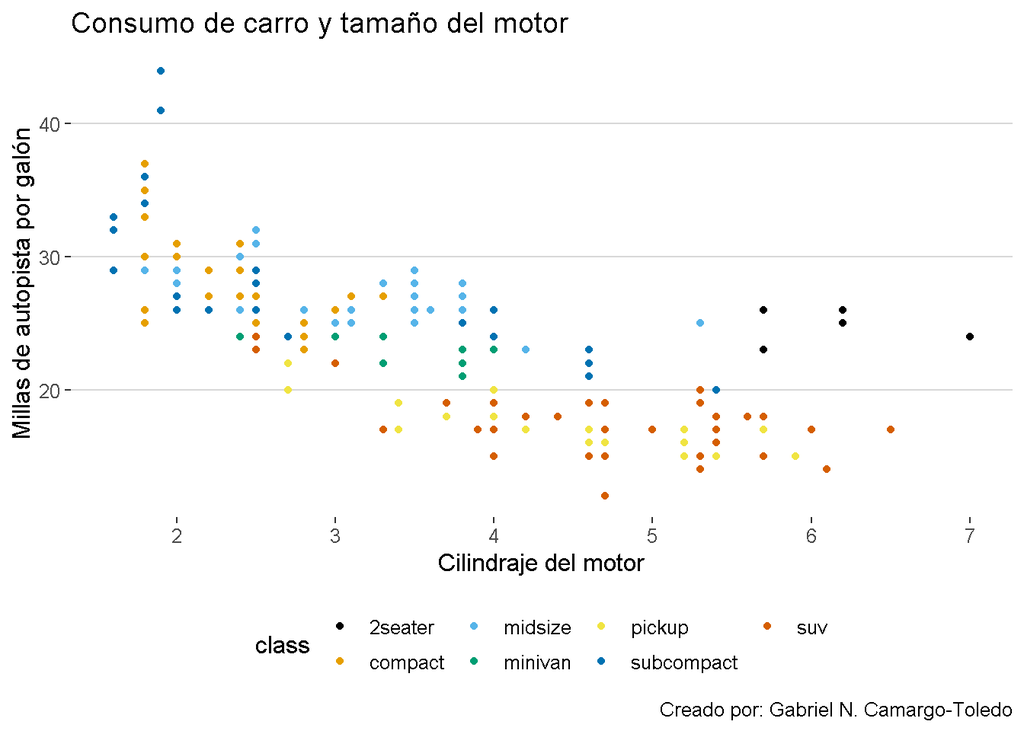

```r
data_plot + poi_plot + text_plot + theme_hc() + scale_colour_manual(values=cbbPal_color)
```

# Paquetes

Los paquetes son lo que hacen a R tan poderosos. Aunque con R básico es posible hacer muchas cosas, la comunidad ha creado muchos paquetes que amplían la funcionalidad de R o hacen la vida más fácil. Saber instalar y usar estos paquetes es fundamental para sacar el mayor provecho a R, y para hacernos nuestra vida más fácil.

## Qué son, cómo se instalan y cómo se usan

Los paquetes son colecciones de funciones, documentación y en algunos casos datos. Cualquier persona puede escribir un paquete. Por eso R es tan flexible. Pero hay que tener cuidado, a veces dos paquetes tienen el mismo nombre de función y se pueden generar conflictos.

Para instalar un paquete hay que usar la función `install.packages`:

```r
install.packages("tidyverse")
```

Solo es necesario instalar los paquetes una vez, o cuando sea necesario actualizarlos. Para que funcione hay que estar conectado a internet.

Pero cada vez que se vaya usar un paquete en una sesión hay que usar `library()`:

```r
library("tidyverse")
```

## Qué es el tidyverse

El [tidyverse](https://www.tidyverse.org/) es una colección de paquetes para R pensados para los científicos de datos, y sus tareas más comunes, que comparten la misma filosofía de diseño, gramática y estructura de los datos. Esto asegura una mayor compatibilidad.

Además su filosofía busca ayudar a que el código de R sea más fácil de leer y entender. Esto hace que haga la curva de aprendizaje se menor, al usar este paquete. También tiene la ventaja de que está auspiciada por Rstudio, una empresa consolidada e importante en el mundo de data science, lo que asegura que va a tener actualizaciones y soporte a largo plazo.

# To R or not to R

## Porqué R

R es software libre. Esto significa que es gratis, y además que se puede modificar desde su código source al antojo. Esto implica que hay mucha gente creando paquetes para muchas cosas. Por esta razón muchos de los estadísticos, econometristas o científicos de datos que están desarrollando técnicas nuevas, las implementan en R.

A diferencia de otros programas estadísticos (SPSS o Stata), R sirve también como un lenguaje de programación general (simulaciones, text analysis, web-scraping). Además, a diferencia de estos, R permite tener varias bases de datos abiertas en la misma sesión y es muy bueno en manejar información en formato texto.

Permite generar reportes dinámicos a distintos formatos: .docx, pdf, html. (usando Rmarkdown y Rstudio)

## Porqué no R

R tiene una curva de aprendizaje empinada. Comparado con otros programas estadísticos suele ser siempre más complejo. Ej. hacer una regresión lineal en R se hace: `lm(x ~ y, data=data)`. En Stata: `reg x y`

R es normalmente más lento que otros programas generales usados para data science (Python, Julia, Go).

# Respuestas

## Gráficos rápidos

- R1/ Esta gráfica tiene unas etiquetas feas y el fondo gris también es feo (aunque ayuda a la legibilidad).
- R2/ ggtitle le añadió un título a la gráfica. El " + " añada cosas a las gráficas, en distintas “capas” (layers). Las capas son lo más poderoso de ggplot, es posible ir creando la gráfica por pasos con distintas capas.

## Capas de un ggplot

- R1/ Usar ambos genera el mismo resultado en la gráfica. Pero `labs` tiene la ventaja que puede incluir otras etiquetas, como captions, subtítulos, ejes, etc.

# Referencias

- https://r4ds.had.co.nz/data-visualisation.html
- https://quantoid.net
- https://xkcd.com/833/
- https://vita.had.co.nz/papers/layered-grammar.pdf
- https://www.cookbook-r.com/Graphs/Colors_(ggplot2)/#a-colorblind-friendly-palette

### Licencia

En la versión Octubre-2020, el código de este tutorial está basado en https://r4ds.had.co.nz/index.html, por lo que no puedo distribuirlo, pues tiene licencia que no permite derivados. Por eso este tutorial no es publicado en la web todavía. Cuando lo sea estará licenciado bajo:

This work by Gabriel N. Camargo-Toledo is licensed under a [Creative Commons Attribution 4.0 International License](http://creativecommons.org/licenses/by/4.0/).